# Leadership: Final (end of the semester)

Irina Benedyk

2026-05-21

# Final (end of the semester) Leadership Competency Analysis

“Engineering leadership consists of capabilities and values that transform technical people from individual contributors into those who can lead teams to deliver a complex multi-disciplinary product” © Gordon-MIT Engineering Leadership Program.

**Cohort:** Civil Engineering student, mostly juniors, *Spring 2026*.

**Course:** Introduction into Transportation System Analysis (for most students this course is the first exposure to the transportation engineering).

This is an analysis of the data for the final leadership survey from 103 respondents, collected in the end of the course to establish impacts of course activities (weekly group assignments and team project), and how these responses relate to initial and mid semester responses.

[Link to the initial survey responses analysis](https://birina-tech.github.io/CIE439_Spring_2026_Leadership_1/)

[Link to the mid-semester survey responses analysis](https://birina-tech.github.io/CIE439_Spring_2026_Leadership_2-mid_semester-/)

Before the education begins, students generally feel most confident in collaborative tasks and least confident in formal leadership and innovation-specific roles. Let’s see how they feel in the end of the course.

## Methodology

This study evaluates leadership competencies among engineering students (mostly juniors) via self-assessment. The evaluation is based on a modified framework by Stevens et al. (2021) and adopts Huckabee’s (2023) definition of leadership: the ability to influence others to reach a specific goal.

**Survey Instrument (exactly the same as the first and second survesy)**

Participants were asked to respond to the following prompt:

“Indicate how well your previous education prepared you for your professional career and enhanced your ability relative to each of the following skills using a 5-point Likert scale: (1) Poorly, (2) Fairly, (3) Neither poorly nor well, (4) Very Well, and (5) Excellently.”

**Evaluated Leadership Dimensions**

- **Leading Teams:** Running meetings and adjusting to personality types.
- **Strategic Thinking:** Using mission and vision statements effectively.
- **Teamwork:** Contributing to high-performing teams.
- **Project Management:** Applying formal processes to technical projects.
- **Feedback:** Mastering the art of professional critique.
- **Self-Reflection:** Ongoing evaluation of leadership growth.
- **Ethical Practice:** Navigating ethical issues and decision-making.
- **Innovation:** Fostering creative team cultures.
- **Global Competencies:** Navigating cross-cultural environments and reducing bias.
- **Emotional Intelligence:** Managing conflict and emotional regulation.
- **Communication:** Tailoring professional writing and speaking to audiences.
- **Initiative:** Taking ownership of new challenges and responsibilities.

“Stevens, J. D., Lang, D., Handley, M., Park, J. J., & Mittan, P. (2021). Evaluating the Effectiveness of an Undergraduate Engineering Leadership Development Minor on Graduates. ASEE Annual Conference and Exposition, Conference Proceedings.”

## Final Cohort Average Scores

The bar chart below depicts the final average scores for each leadership metric at the end of the semester.

**Highest Final Proficiency:** By the end of the course, following the completion of the major team project, students rate themselves highest in Emotional Intelligence and Communication. This suggests that the intensive, collaborative nature of the course project solidified their confidence in these core team-important dynamics.

**Areas of Greatest Challenge:** While all scores have generally shifted upward since the beginning of the semester, Leading Teams, Project Management, and Innovation Culture remain the lowest relatively. This suggests that while students feel highly capable as team members (Teamwork), stepping into formal management roles and inspire others remains a complex challenge that requires ongoing professional development in civil engineering students beyond this course.

[figure not shown]

## Distribution of Ratings

A stacked bar chart shows the “spread” or distribution of student confidence at the end of the semester.

In this final iteration of the survey, the frequency of $1$ (Poorly) and $2$ (Fairly) ratings has diminished significantly compared to the baseline and mid semester surveys. The vast majority of the cohort now places themselves in the $4$ (Very Well) and $5$ (Excellently) categories across almost all metrics.

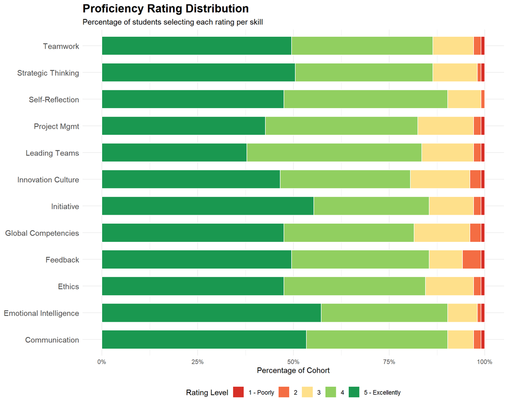

## Longitudinal Growth

To fully estimate the impact of the curriculum, next two visualizations demonstrate how students’ self-perceived leadership competencies evolved from the baseline to the end of the semester.

It is important to note here, that students have other courses and these impacts can’t be attributed only to CIE439 curriculum!

The following longitudinal visualizations map changes in self-evaluation across all three assessment periods. The trajectory chart illustrates the incremental growth phases driven by weekly group activities (from *Initial* to *Mid*) and the intensive final team project (from *Mid* to *Final*), while the dumbbell plot highlights the absolute *distance traveled* for each skill by directly comparing the initial and final survey results.

Together, these charts provide compelling evidence of a comprehensive, positive shift in student confidence across all measured dimensions of engineering leadership during Spring semeter.

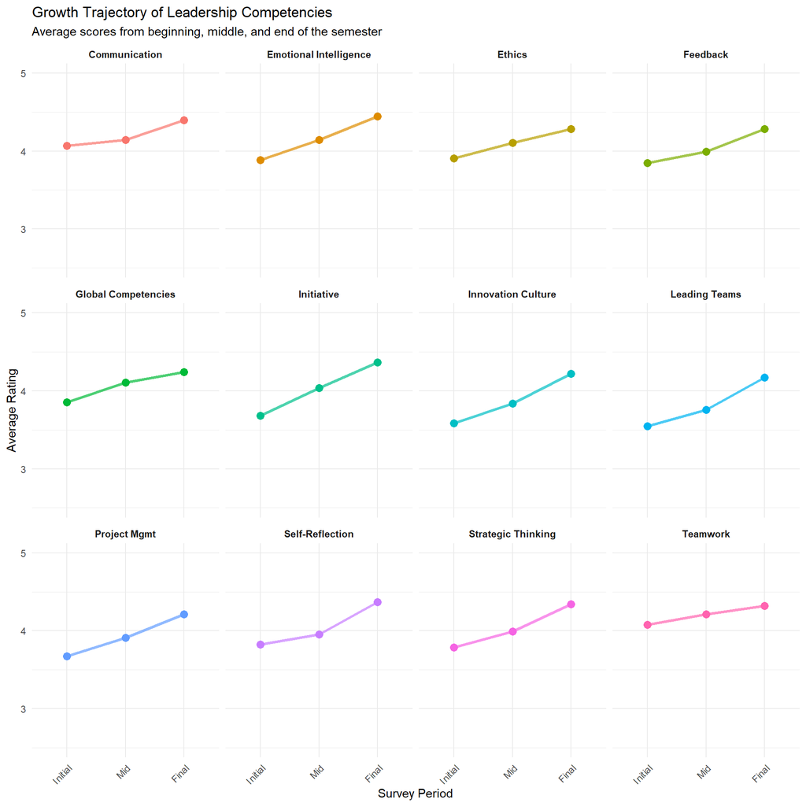

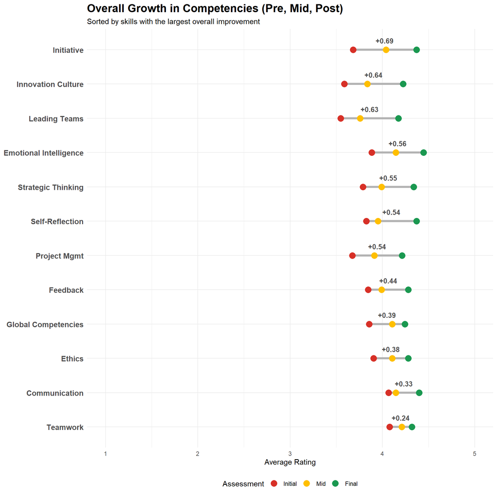